# Tweedie vs Poisson * Gamma

Simon

2020-03-23

I’m building my first tweedie model, and I’m finally trying the {recipes} package.

We will try to predict the pure premium of car insurance policy. This can be done directly with a tweedie model, or by multiplying two separates models: a frequency (Poisson) and a severity (Gamma) model. We wil be using “lift charts” and “double lift charts” to evaluate the model performance .

More details about these charts here](https://www.casact.org/education/rpm/2015/handouts/Paper_4034_handout_2419_0.pdf). That link says “simple quantile plots” instead of “Lift charts”.

tl;dr: the glm and xgboost models all perform poorly, but man do I like recipes!!!

# Libraries

```r
# https://www.cybaea.net/Journal/2012/03/13/R-code-for-Chapter-2-of-Non_Life-Insurance-Pricing-with-GLM/
library(insuranceData) # pour les données dataCar
library(tidyverse)  # pour la manipulation de données
library(statmod) #pour glm(family = tweedie)
library(modelr) # pour add_predictions()
library(broom) # pour afficher les coefficients
library(tidymodels)
library(xgboost)
library(tictoc)
library(dviz.supp) # devtools::install_github("clauswilke/dviz.supp")
library(colorblindr)  # devtools::install_github("clauswilke/colorblindr")
library(patchwork)
library(rsample)
library(yardstick)
library(recipes)
```

# Data

The dataCar data from the `insuranceData` package. It contains 67 856 one-year vehicle insurance policies taken out in 2004 or 2005.

The `exposure` variable represents the “number of year of exposure” and is used as the offset variable. It is bounded between 0 and 1.

Finally, the independent variables are as follow:

- `veh_value`, the vehicle value in tens of thousand of dollars,
- `veh_body`, y vehicle body, coded as BUS CONVT COUPE HBACK HDTOP MCARA MIBUS PANVN RDSTR SEDAN STNWG TRUCK UTE,
- `veh_age`, 1 (youngest), 2, 3, 4,
- `gender`, a factor with levels F M,
- `area` a factor with levels A B C D E F,
- `agecat` 1 (youngest), 2, 3, 4, 5, 6

The dollar amount of the claims is `claimcst0`. We will divide it by the exposure to obtain `annual_loss` which is the pure annual premium.

For the frequency (Poisosn) model, we will model clm (0 or 1) because the cost variables (claimcst0) represents the total cost, if you have multiple claims (numclaims>1).

# Recipe

I’ve used a few tutorials and vignettes, including the following two:

https://cran.r-project.org/web/packages/recipes/vignettes/Simple_Example.html https://www.andrewaage.com/post/a-simple-solution-to-a-kaggle-competition-using-xgboost-and-recipes/

```r
data(dataCar)

# claimcst0claim amount (0 if no claim)
# clm = 0 or 1. numclaims = 0 , 1 ,2 ,3 or 4.. on va essayer clm (0-1).. car j'ai un claimcst0 représente
mydb <- dataCar %>% select(clm, claimcst0, exposure, veh_value, veh_body,
                           veh_age, gender, area, agecat) %>%
  mutate(annual_loss = claimcst0 / exposure)

set.seed(42)

split <- rsample::initial_split(mydb, prop = 0.8)
train <- rsample::training(split)
test <- rsample::testing(split)

rec <-  recipes::recipe(train %>% select(annual_loss, clm, claimcst0,  exposure, veh_value,veh_body, veh_age, gender,area,agecat)) %>%
  recipes::update_role(everything(), new_role = "predictor") %>%
  recipes::update_role(annual_loss, new_role = "outcome") %>%
  recipes::update_role(clm, new_role = "outcome") %>%
  recipes::update_role(claimcst0, new_role = "outcome") %>%
  recipes::update_role(exposure, new_role = "case weight") %>%
  recipes::step_zv(recipes::all_predictors()) %>%   # remove variable with all equal values
  recipes::step_other(recipes::all_predictors(), threshold = 0.01)  %>%       # combine categories with less than 1% of observation
  recipes::step_dummy(recipes::all_nominal())  %>% # convert to dummy for xgboost use
  check_missing(all_predictors()) ## break the bake function if any of the checked columns contains NA value

# Prepare the recipe and use juice/bake to get the data!
prepped_rec <- prep(rec)
train <- juice(prepped_rec)
test <- bake(prepped_rec, new_data = test)
```

# GLMs

## Tweedie model (pure premium)

the model isnt very impressive, with only agecat and the itnercept having a nice p-value..

```r
tweedie_fit <-
  glm(annual_loss ~ . -exposure -clm -claimcst0,
      family=tweedie(var.power=1.1, link.power=0),
      weights = exposure,
      data = train)

summary(tweedie_fit)
```

```
##
## Call:
## glm(formula = annual_loss ~ . - exposure - clm - claimcst0, family = tweedie(var.power = 1.1,
##     link.power = 0), data = train, weights = exposure)
##
## Deviance Residuals:
##    Min      1Q  Median      3Q     Max
## -30.73  -15.27  -11.69   -7.48  522.10
##
## Coefficients:
##                 Estimate Std. Error t value Pr(>|t|)
## (Intercept)      6.93764    0.93968   7.383 1.57e-13 ***
## veh_age         -0.03101    0.06872  -0.451  0.65178
## agecat          -0.14893    0.05180  -2.875  0.00404 **
## veh_value_other -0.16847    0.73587  -0.229  0.81891
## veh_body_HBACK  -0.64085    0.54507  -1.176  0.23972
## veh_body_HDTOP  -0.48669    0.66056  -0.737  0.46126
## veh_body_MIBUS  -0.28068    0.80548  -0.348  0.72749
## veh_body_PANVN  -0.50868    0.77672  -0.655  0.51253
## veh_body_SEDAN  -0.73611    0.54332  -1.355  0.17548
## veh_body_STNWG  -0.66902    0.54715  -1.223  0.22144
## veh_body_TRUCK  -0.66588    0.67257  -0.990  0.32215
## veh_body_UTE    -1.02284    0.61274  -1.669  0.09507 .
## veh_body_other  -0.63826    1.21988  -0.523  0.60082
## gender_M         0.17536    0.14910   1.176  0.23956
## area_B           0.03934    0.22307   0.176  0.86000
## area_C           0.11221    0.19871   0.565  0.57228
## area_D          -0.06155    0.27269  -0.226  0.82142
## area_E           0.17425    0.28427   0.613  0.53990
## area_F           0.50916    0.29573   1.722  0.08513 .
## ---
## Signif. codes:  0 '***' 0.001 '**' 0.01 '*' 0.05 '.' 0.1 ' ' 1
##
## (Dispersion parameter for Tweedie family taken to be 21321.71)
##
##     Null deviance: 27467208  on 54284  degrees of freedom
## Residual deviance: 27072876  on 54266  degrees of freedom
## AIC: NA
##
## Number of Fisher Scoring iterations: 9
```

## Poisson model (frequency)

```r
poisson_fit <-
  glm(clm ~ . -annual_loss -exposure -claimcst0 ,
      family = poisson(link = "log"),
      offset = log(exposure),
      data = train)

#broom::tidy(poisson_fit)
summary(poisson_fit)
```

```
##
## Call:
## glm(formula = clm ~ . - annual_loss - exposure - claimcst0, family = poisson(link = "log"),
##     data = train, offset = log(exposure))
##
## Deviance Residuals:
##     Min       1Q   Median       3Q      Max
## -0.7845  -0.4357  -0.3342  -0.2141   3.7458
##
## Coefficients:
##                 Estimate Std. Error z value Pr(>|z|)
## (Intercept)     -1.17070    0.24103  -4.857 1.19e-06 ***
## veh_age         -0.06614    0.01583  -4.179 2.93e-05 ***
## agecat          -0.08207    0.01190  -6.894 5.42e-12 ***
## veh_value_other  0.05618    0.19015   0.295  0.76764
## veh_body_HBACK  -0.42944    0.14042  -3.058  0.00223 **
## veh_body_HDTOP  -0.29780    0.16945  -1.757  0.07884 .
## veh_body_MIBUS  -0.35012    0.21531  -1.626  0.10393
## veh_body_PANVN  -0.22424    0.19193  -1.168  0.24267
## veh_body_SEDAN  -0.39995    0.13973  -2.862  0.00420 **
## veh_body_STNWG  -0.34514    0.14075  -2.452  0.01420 *
## veh_body_TRUCK  -0.42734    0.17255  -2.477  0.01326 *
## veh_body_UTE    -0.61040    0.15493  -3.940 8.16e-05 ***
## veh_body_other   0.17814    0.24225   0.735  0.46212
## gender_M        -0.01338    0.03479  -0.385  0.70051
## area_B           0.09313    0.04979   1.870  0.06143 .
## area_C           0.06341    0.04542   1.396  0.16270
## area_D          -0.07332    0.06175  -1.187  0.23508
## area_E          -0.03182    0.06849  -0.465  0.64220
## area_F           0.08944    0.07681   1.164  0.24423
## ---
## Signif. codes:  0 '***' 0.001 '**' 0.01 '*' 0.05 '.' 0.1 ' ' 1
##
## (Dispersion parameter for poisson family taken to be 1)
##
##     Null deviance: 18959  on 54284  degrees of freedom
## Residual deviance: 18850  on 54266  degrees of freedom
## AIC: 26206
##
## Number of Fisher Scoring iterations: 6
```

## Gamma model

```r
gamma_fit <-
  glm(claimcst0 ~ . -annual_loss -exposure -clm ,
      data = train %>% filter( claimcst0 > 0),
      family = Gamma("log"))

#broom::tidy(gamma_fit)
summary(gamma_fit)
```

```
##
## Call:
## glm(formula = claimcst0 ~ . - annual_loss - exposure - clm, family = Gamma("log"),
##     data = train %>% filter(claimcst0 > 0))
##
## Deviance Residuals:
##     Min       1Q   Median       3Q      Max
## -1.9859  -1.3684  -0.8208   0.0511   6.8822
##
## Coefficients:
##                 Estimate Std. Error t value Pr(>|t|)
## (Intercept)      8.00288    0.42385  18.882  < 2e-16 ***
## veh_age          0.04901    0.02809   1.744  0.08116 .
## agecat          -0.06398    0.02088  -3.064  0.00220 **
## veh_value_other -0.18949    0.33484  -0.566  0.57148
## veh_body_HBACK  -0.17503    0.24754  -0.707  0.47956
## veh_body_HDTOP  -0.20753    0.29798  -0.696  0.48619
## veh_body_MIBUS   0.08783    0.37897   0.232  0.81675
## veh_body_PANVN  -0.25758    0.33745  -0.763  0.44533
## veh_body_SEDAN  -0.30662    0.24656  -1.244  0.21374
## veh_body_STNWG  -0.31731    0.24821  -1.278  0.20119
## veh_body_TRUCK  -0.19878    0.30433  -0.653  0.51367
## veh_body_UTE    -0.39258    0.27305  -1.438  0.15059
## veh_body_other  -0.81729    0.42653  -1.916  0.05543 .
## gender_M         0.19268    0.06126   3.146  0.00167 **
## area_B          -0.06782    0.08761  -0.774  0.43894
## area_C           0.05637    0.08006   0.704  0.48141
## area_D           0.01732    0.10891   0.159  0.87363
## area_E           0.18760    0.12097   1.551  0.12106
## area_F           0.43326    0.13583   3.190  0.00144 **
## ---
## Signif. codes:  0 '***' 0.001 '**' 0.01 '*' 0.05 '.' 0.1 ' ' 1
##
## (Dispersion parameter for Gamma family taken to be 3.093011)
##
##     Null deviance: 5907.8  on 3658  degrees of freedom
## Residual deviance: 5754.2  on 3640  degrees of freedom
## AIC: 62795
##
## Number of Fisher Scoring iterations: 7
```

# XGBoost

## XGBoost Tweedie Model

```r
xgtrain_tweedie <- xgb.DMatrix(as.matrix(train %>% select(-annual_loss ,-clm, - claimcst0, -exposure )),
                               label = train$annual_loss,
                               weight = train$exposure
)


xgtest_tweedie <- xgb.DMatrix(as.matrix(test %>% select(-annual_loss ,-clm, - claimcst0, -exposure )),
                              label = test$annual_loss,
                              weight = test$exposure
)



params <-list(
  booster = "gbtree",
  objective = 'reg:tweedie',
  eval_metric = "tweedie-nloglik@1.1",
  tweedie_variance_power = 1.1,
  gamma = 0,
  max_depth = 4,
  eta = 0.01,
  min_child_weight = 3,
  subsample = 0.8,
  colsample_bytree = 0.8,
  tree_method = "hist"
)

xgcv_tweedie <- xgb.cv(
  params = params,
  data = xgtrain_tweedie,
  nround = 1000,
  nfold=  5,
  showsd = TRUE,
  early_stopping_rounds = 50,
  verbose = 0)

xgcv_tweedie$best_iteration
```

```
## [1] 314
```

```r
# xgb.cv doesnt ouput any model -- we need a model to predict test dataset
xgmodel_tweedie <- xgboost::xgb.train(
  data = xgtrain_tweedie,
  params = params,
  nrounds = xgcv_tweedie$best_iteration,
  nthread = parallel::detectCores() - 1
)
```

## XGBoost Poisson model

```r
xgtrain_poisson <- xgb.DMatrix(as.matrix(train %>% select(-annual_loss ,-clm, - claimcst0, -exposure )),
                               label = train$clm
)


xgtest_poisson <- xgb.DMatrix(as.matrix(test %>% select(-annual_loss ,-clm, - claimcst0, -exposure )),
                              label = test$clm
)

setinfo(xgtrain_poisson,"base_margin",
        train %>% pull(exposure) %>% log() )
```

```
## [1] TRUE
```

```r
setinfo(xgtest_poisson,"base_margin",
        train %>% pull(exposure) %>% log() )
```

```
## [1] TRUE
```

```r
params <-list(
  booster = "gbtree",
  objective = 'count:poisson',
  eval_metric = "poisson-nloglik",
  gamma = 0,
  max_depth = 4,
  eta = 0.05,
  min_child_weight = 3,
  subsample = 0.8,
  colsample_bytree = 0.8,
  tree_method = "hist"
)

xgcv_poisson <- xgb.cv(
  params = params,
  data = xgtrain_poisson,
  nround = 1000,
  nfold=  5,
  showsd = TRUE,
  early_stopping_rounds = 50,
  verbose = 0)

xgcv_poisson$best_iteration
```

```
## [1] 206
```

```r
# xgb.cv doesnt ouput any model -- we need a model to predict test dataset
xgmodel_poisson <- xgboost::xgb.train(
  data = xgtrain_poisson,
  params = params,
  nrounds = xgcv_poisson$best_iteration,
  nthread = parallel::detectCores() - 1
)
```

## XGBoost Gamma model

Gamma model is only train on policy with claims

```r
xgtrain_gamma <- xgb.DMatrix(as.matrix(train %>% filter(claimcst0 > 0) %>%select(-annual_loss ,-clm, - claimcst0, -exposure )),
                             label = train %>% filter(claimcst0 > 0) %>% pull(claimcst0)
)


xgtest_gamma <- xgb.DMatrix(as.matrix(test %>% select(-annual_loss ,-clm, - claimcst0, -exposure )),
                            label = test$claimcst0
)

params <-list(
  booster = "gbtree",
  objective = 'reg:gamma',
  gamma = 0,
  max_depth = 4,
  eta = 0.05,
  min_child_weight = 3,
  subsample = 0.8,
  colsample_bytree = 0.8,
  tree_method = "hist"
)

xgcv_gamma <- xgb.cv(
  params = params,
  data = xgtrain_gamma,
  nround = 1000,
  nfold=  5,
  showsd = TRUE,
  early_stopping_rounds = 50,
  verbose = 0)

xgcv_gamma$best_iteration
```

```
## [1] 221
```

```r
# xgb.cv doesnt ouput any model -- we need a model to predict test dataset
xgmodel_gamma <- xgboost::xgb.train(
  data = xgtrain_gamma,
  params = params,
  nrounds = xgcv_gamma$best_iteration,
  nthread = parallel::detectCores() - 1
)
```

# Functions lift & double lift

```r
# double lift charts

#' @title disloc()
#'
#' @description Cette fonction crée un tableau et une double lift chart
#' @param data data.frame  source
#' @param pred1 prediction of first model
#' @param pred1 prediction of second model
#' @param expo exposure var
#' @param obs observed result
#' @param nb nombre de quantils créés
#' @param obs_lab Label pour la valeur observée dans le graphique
#' @param pred1_lab Label pour la première prédiction dans le graphique
#' @param pred2_lab Label pour la deuxième prédiction dans le graphique
#' @param x_label Label pour la valeur réalisée dans le graphique
#' @param y_label Label pour la valeur réalisée dans le graphique
#' @param y_format Fonction utilisée pour formater l'axe des y dans le graphique (par exemple percent_format() ou dollar_format() du package scales)
#' @export


disloc <- function(data, pred1, pred2, expo, obs, nb = 10,
                   obs_lab = "",
                   pred1_lab = "", pred2_lab = "",
                   x_label = "",
                   y_label= "sinistralité",
                   y_format = scales::number_format(accuracy = 1,  big.mark = " ", decimal.mark = ",")
) {
  # obligé de mettre les variables dans un enquo pour pouvoir les utiliser dans dplyr

  pred1_var <- enquo(pred1)
  pred2_var <- enquo(pred2)
  expo_var <- enquo(expo)
  obs_var <- enquo(obs)


  pred1_name <- quo_name(pred1_var)
  pred2_name <- quo_name(pred2_var)
  obs_name <- quo_name(obs_var)


  if (pred1_lab =="") {pred1_lab <- pred1_name}
  if (pred2_lab =="") {pred2_lab <- pred2_name}
  if (obs_lab =="") {obs_lab <- obs_name}

  if (x_label == ""){ x_label <- paste0("ratio entre les prédictions ", pred1_lab, " / ", pred2_lab)}

  # création de la comparaison entre les deux pred
  dd <- data %>%
    mutate(ratio = !!pred1_var / !!pred2_var) %>%
    filter(!!expo_var > 0) %>%
    drop_na()

  # constitution des buckets de poids égaux
  dd <- dd %>% add_equal_weight_group(
    sort_by = ratio,
    expo = !!expo_var,
    group_variable_name = "groupe",
    nb = nb
  )

  # comparaison sur ces buckets
  dd <- full_join(
    dd %>% group_by(groupe) %>%
      summarise(
        ratio_moyen = mean(ratio),
        ratio_min = min(ratio),
        ratio_max = max(ratio)
      ),
    dd %>% group_by(groupe) %>%
      summarise_at(
        funs(sum(.) / sum(!!expo_var)),
        .vars = vars(!!obs_var, !!pred1_var, !!pred2_var)
      ) %>%
      ungroup,
    by = "groupe"
  )

  # création des labels
  dd <- dd %>%
    mutate(labs = paste0("[", round(ratio_min, 2), ", ", round(ratio_max, 2), "]"))

  # graphe
  plotdata <-
    dd %>%
    gather(key, variable, !!obs_var, !!pred1_var, !!pred2_var) %>%
    ## Pas optimal mais je ne trouve pas mieux...
    mutate(key = case_when(
      key == obs_name ~ obs_lab,
      key == pred1_name ~ pred1_lab,
      key == pred2_name ~ pred2_lab
    )) %>%
    mutate(key = factor(key, levels = c(obs_lab, pred1_lab, pred2_lab), ordered = TRUE))

  pl <- plotdata %>%
    ggplot(aes(ratio_moyen, variable, color = key, linetype = key)) +
    cowplot::theme_cowplot() +
    cowplot::background_grid()+
    colorblindr::scale_color_OkabeIto( ) +

    scale_x_continuous(breaks = scales::pretty_breaks())+
    geom_line() +
    geom_point() +
    scale_x_continuous(breaks = dd$ratio_moyen, labels = dd$labs) +
    scale_y_continuous(breaks = scales::pretty_breaks() )+
    labs(
      x = x_label,
      y = y_label
    )+
    theme(axis.text.x = element_text(angle = 30, hjust = 1, vjust = 1)) #+


  # écart au réalisé, pondéré
  ecart <- dd %>%
    mutate(poids = abs(1 - ratio_moyen)) %>%
    summarise_at(
      vars(!!pred1_var, !!pred2_var),
      funs(weighted.mean((. - !!obs_var)^2, w = poids) %>% sqrt())
    ) %>% summarise(ratio_distance = !!pred2_var / !!pred1_var) %>%
    as.numeric()

  list(
    graphe = pl,
    ecart = ecart,
    tableau = dd
  )
}



#' @title add_equal_weight_group()
#'
#' @description Cette fonction crée des groupe (quantiles) avec le nombre nombre total d'exposition.
#' @param table data.frame  source
#' @param sort_by Variable utilisée pour trier les observations.
#' @param expo Exposition (utilisée pour créer des quantiles de la même taille.  Si NULL, l'exposition est égale pour toutes les observations) (Défault = NULL).
#' @param nb Nombre de quantiles crées (défaut = 10)
#' @param group_variable_name Nom de la variable de groupes créée
#' @export


add_equal_weight_group <- function(table, sort_by, expo = NULL, group_variable_name = "groupe", nb = 10) {
  sort_by_var <- enquo(sort_by)
  groupe_variable_name_var <- enquo(group_variable_name)

  if (!(missing(expo))){ # https://stackoverflow.com/questions/48504942/testing-a-function-that-uses-enquo-for-a-null-parameter

    expo_var <- enquo(expo)

    total <- table %>% pull(!!expo_var) %>% sum
    br <- seq(0, total, length.out = nb + 1) %>% head(-1) %>% c(Inf) %>% unique
    table %>%
      arrange(!!sort_by_var) %>%
      mutate(cumExpo = cumsum(!!expo_var)) %>%
      mutate(!!group_variable_name := cut(cumExpo, breaks = br, ordered_result = TRUE, include.lowest = TRUE) %>% as.numeric) %>%
      select(-cumExpo)
  } else {
    total <- nrow(table)
    br <- seq(0, total, length.out = nb + 1) %>% head(-1) %>% c(Inf) %>% unique
    table %>%
      arrange(!!sort_by_var) %>%
      mutate(cumExpo = row_number()) %>%
      mutate(!!group_variable_name := cut(cumExpo, breaks = br, ordered_result = TRUE, include.lowest = TRUE) %>% as.numeric) %>%
      select(-cumExpo)
  }
}

get_lift_chart_data <- function(
  data,
  sort_by,
  pred,
  expo,
  obs,
  nb = 10) {

  pred_var <- enquo(pred)
  sort_by_var <- enquo(sort_by)
  expo_var <- enquo(expo)
  obs_var <- enquo(obs)


  pred_name <- quo_name(pred_var)
  sort_by_name <- quo_name(sort_by_var)
  obs_name <- quo_name(obs_var)

  # constitution des buckets de poids égaux
  dd <- data %>% add_equal_weight_group(
    sort_by = !!sort_by_var,
    expo = !!expo_var,
    group_variable_name = "groupe",
    nb = nb
  )

  # comparaison sur ces buckets
  dd <- full_join(
    dd %>%
      group_by(groupe) %>%
      summarise(
        exposure = sum(!!expo_var),
        sort_by_moyen = mean(!!sort_by_var),
        sort_by_min = min(!!sort_by_var),
        sort_by_max = max(!!sort_by_var)
      ) %>%
      ungroup(),
    dd %>%
      group_by(groupe) %>%
      summarise_at(
        funs(sum(.) / sum(!!expo_var)),
        .vars = vars(!!obs_var, !!pred_var)
      ) %>%
      ungroup,
    by = "groupe"
  )

  # création des labels
  dd <- dd %>%
    mutate(labs = paste0("[", round(sort_by_min, 2), ", ", round(sort_by_max, 2), "]"))

}



get_lift_chart <- function(data,
                           sort_by,
                           pred,
                           expo,
                           obs,
                           nb){

  pred_var <- enquo(pred)
  sort_by_var <- enquo(sort_by)
  expo_var <- enquo(expo)
  obs_var <- enquo(obs)

  lift_data <- get_lift_chart_data(
    data = data,
    sort_by = !!sort_by_var,
    pred = !!pred_var,
    expo = !!expo_var,
    obs = !!obs_var,
    nb = 10)

  p1 <- lift_data %>%
    mutate(groupe = as.factor(groupe)) %>%
    select(groupe, labs, !!pred_var, !!obs_var) %>%
    gather(key = type, value = average, !!pred_var, !!obs_var)  %>%
    ggplot(aes(x= groupe, y = average, color =type, group = type)) +
    geom_line() +
    geom_point()+
    cowplot::theme_half_open() +
    cowplot::background_grid() +
    colorblindr::scale_color_OkabeIto( ) +
    # scale_y_continuous(
    #   breaks  = scales::pretty_breaks()
    # )+
    theme(
      legend.position = c(0.1, 0.8),
      axis.title.x=element_blank(),
      axis.text.x=element_blank(),
      axis.ticks.x=element_blank()
    )

  p2 <- lift_data %>%
    mutate(groupe = as.factor(groupe)) %>%
    select(groupe, labs, exposure) %>%
    ggplot(aes(x= groupe, y = exposure)) +
    geom_col() +
    cowplot::theme_half_open() +
    cowplot::background_grid() +
    colorblindr::scale_color_OkabeIto( )# +
    # scale_y_continuous(
    #   expand = c(0,0),
    #   breaks  = scales::breaks_pretty(3)
    # )

  return(p1 / p2 +   plot_layout(heights = c(3, 1)))
}
```

# Add predictions to test database.

Quick check: the means for predictions of frequency and total cost don’t appear to be way off

```r
test_w_preds <- test %>%
  add_predictions("pred_annual_loss_glm", model = tweedie_fit, type = "response") %>%
  mutate(pred_loss_glm = pred_annual_loss_glm * exposure) %>%
  add_predictions("pred_poisson_glm", model = poisson_fit, type = "response") %>%
  add_predictions("pred_gamma_glm", model = gamma_fit, type = "response")  %>%
  mutate(pred_frequency_severity_glm = pred_poisson_glm * pred_gamma_glm,
         pred_annual_loss_xgboost = predict(xgmodel_tweedie, xgtest_tweedie),
         pred_loss_xgboost = pred_annual_loss_xgboost * exposure,
         pred_poisson_xgboost =  predict(xgmodel_poisson, xgtest_poisson),
         pred_gamma_xgboost =  predict(xgmodel_gamma, xgtest_gamma),
         pred_frequency_severity_xgboost = pred_poisson_xgboost * pred_gamma_xgboost,
         pred_annual_freq_glm = pred_poisson_glm / exposure,
         pred_annual_freq_xgboost = pred_poisson_xgboost / exposure,)


test_w_preds %>%
  select(claimcst0, pred_loss_glm, pred_frequency_severity_glm, pred_loss_xgboost, pred_frequency_severity_xgboost,
         clm, pred_poisson_glm, pred_poisson_xgboost) %>%
  summary()
```

```
##    claimcst0       pred_loss_glm      pred_frequency_severity_glm
##  Min.   :    0.0   Min.   :  0.4129   Min.   :  0.4169
##  1st Qu.:    0.0   1st Qu.: 58.8170   1st Qu.: 58.8756
##  Median :    0.0   Median :120.7763   Median :120.8617
##  Mean   :  140.2   Mean   :136.0306   Mean   :136.0360
##  3rd Qu.:    0.0   3rd Qu.:194.1813   3rd Qu.:194.5117
##  Max.   :23722.4   Max.   :705.1045   Max.   :704.3376
##  pred_loss_xgboost  pred_frequency_severity_xgboost      clm
##  Min.   :   0.335   Min.   : 54.68                  Min.   :0.00000
##  1st Qu.:  52.854   1st Qu.:111.67                  1st Qu.:0.00000
##  Median : 108.431   Median :132.77                  Median :0.00000
##  Mean   : 124.961   Mean   :134.34                  Mean   :0.07111
##  3rd Qu.: 176.297   3rd Qu.:147.29                  3rd Qu.:0.00000
##  Max.   :6452.642   Max.   :725.16                  Max.   :1.00000
##  pred_poisson_glm    pred_poisson_xgboost
##  Min.   :0.0002612   Min.   :0.03877
##  1st Qu.:0.0307849   1st Qu.:0.06683
##  Median :0.0623851   Median :0.07515
##  Mean   :0.0673485   Mean   :0.07454
##  3rd Qu.:0.0999587   3rd Qu.:0.08151
##  Max.   :0.3341072   Max.   :0.17767
```

# Lift charts of select models

## Tweedie lift charts (pure premium)

### GLM

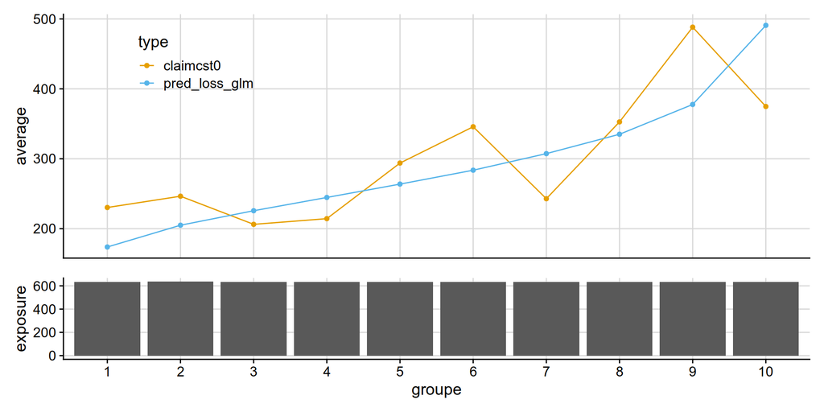

```r
get_lift_chart(
  data = test_w_preds,
  sort_by= pred_annual_loss_glm,
  pred = pred_loss_glm,
  obs = claimcst0,
  expo  = exposure )
```

### XGBoost

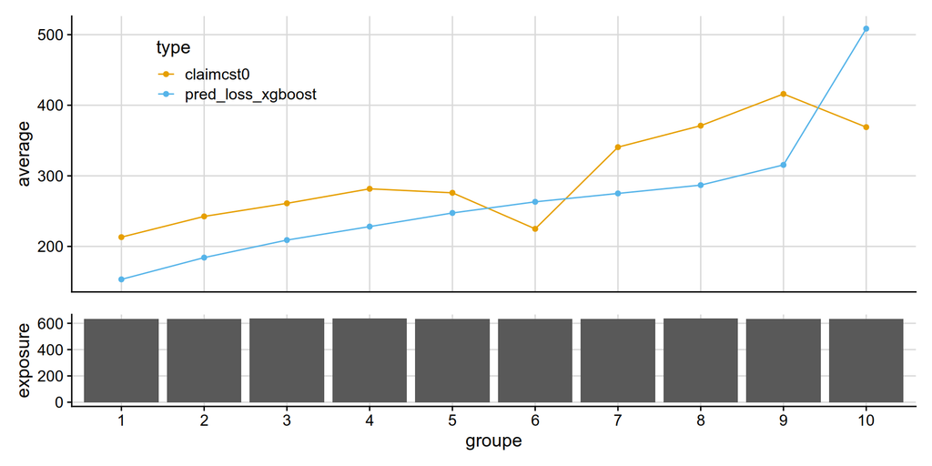

```r
get_lift_chart(
  data = test_w_preds,
  sort_by= pred_annual_loss_xgboost,
  pred = pred_loss_xgboost,
  obs = claimcst0,
  expo  = exposure )
```

## lift chart Poisson (frequency)

### GLM

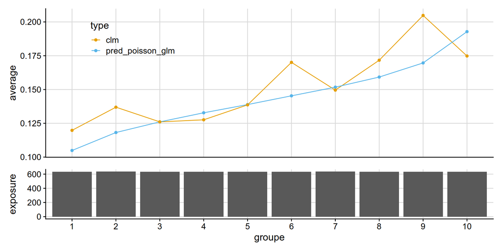

```r
get_lift_chart(
  data = test_w_preds,
  sort_by= pred_annual_freq_glm,
  pred = pred_poisson_glm,
  obs = clm,
  expo  = exposure )
```

### XGBoost

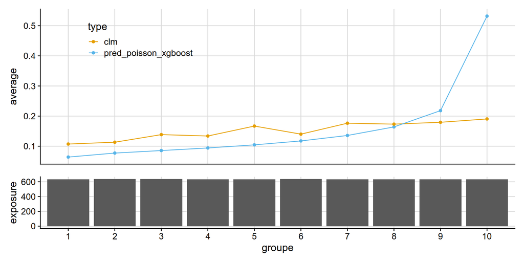

```r
get_lift_chart(
  data = test_w_preds,
  sort_by= pred_annual_freq_xgboost,
  pred = pred_poisson_xgboost,
  obs = clm,
  expo  = exposure )
```

### test: extract individual plot from patchwork (it works!)

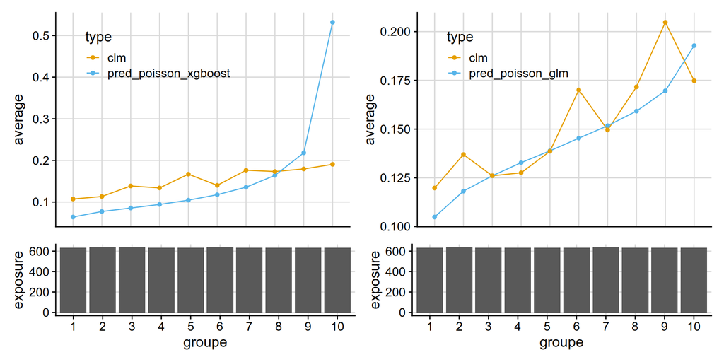

```r
gaa2 <- get_lift_chart(
  data = test_w_preds,
  sort_by= pred_annual_freq_glm,
  pred = pred_poisson_glm,
  obs = clm,
  expo  = exposure )

gaa1 <- get_lift_chart(
  data = test_w_preds,
  sort_by= pred_annual_freq_xgboost,
  pred = pred_poisson_xgboost,
  obs = clm,
  expo  = exposure )

(gaa1[[1]] + gaa2[[1]]) /(gaa1[[2]] + gaa2[[2]])  +    plot_layout(heights = c(3, 1))
```

# Double lift chart

## GLM Tweedie vs GLM Poisson * Gamma

GLM Tweedie ( power = 1.1) appears similar to than Poisson * Gamma .

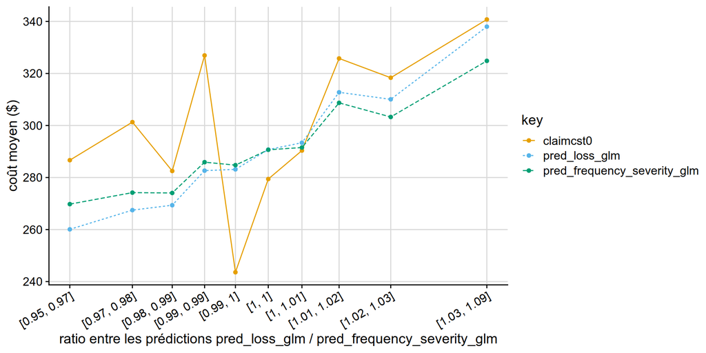

```r
disloc(data = test_w_preds,
       pred1 = pred_loss_glm,
       pred2 = pred_frequency_severity_glm,
       expo = exposure,
       obs = claimcst0 ,
       y_label = "coût moyen ($)"
) %>% .$graphe
```

## GLM Tweedie vs XGB Tweedie

Why is the xgboost tweedie doing so poorly vs GLM tweedie?  
partial answer: xgboost is out of fold, glm can try to overfit.. but it really doesnt have that many variables to overfit on.

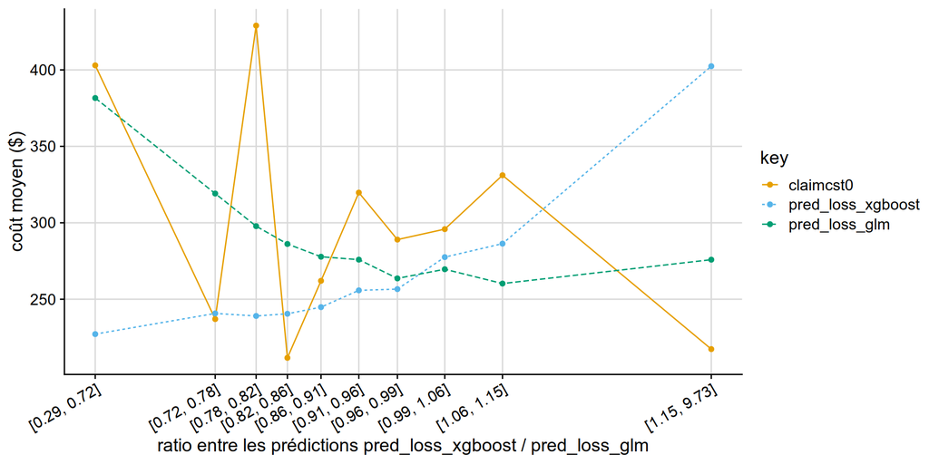

```r
disloc(data = test_w_preds,
       pred1 = pred_loss_xgboost ,
       pred2 = pred_loss_glm,
       expo = exposure,
       obs = claimcst0 ,
       y_label = "coût moyen ($)"
) %>% .$graphe
```

## GLM Poisson*Gamma vs XGB Poisson*Gamma

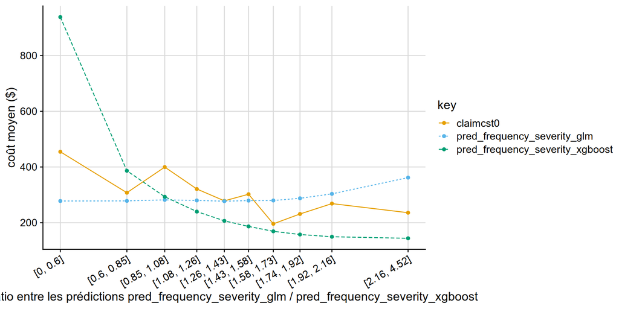

```r
disloc(data = test_w_preds,
       pred1 = pred_frequency_severity_glm,
       pred2 = pred_frequency_severity_xgboost,
       expo = exposure,
       obs = claimcst0 ,
       y_label = "coût moyen ($)"
) %>% .$graphe
```